# MPF: Trabajo Práctico 1, Parte A

Gonzalo Barrera Borla, Gerardo Mitas

November 1, 2016

## Setup Inicial

Antes de proceder con la resolución de las consignas, debemos cargar las librerías a utilizar, y los marcos con la data a analizar. También aprovecharemos para dar nombres mas descriptivos a algunas variables de interés:

```r
# Packages:
library(moments)
library(stratification)
library(car)
library(PracTools)
library(sampling)
library(dplyr)

# Data de prueba
load("data/Prueba.Piloto.RData")

# Doy nombres mas descriptivos a las variables del Piloto
POpiloto = Prueba.Piloto$x
VMPpiloto = Prueba.Piloto$y

# Cargo el Marco completo
load("data/Marco.PO.RData")

# Doy nombres mas descriptivos a las variables del Marco
POmarco = Marco.PO$PO
```

Se pueden ejecutar algunos comandos para explorar la data si así se desea:

```r
summary(Prueba.Piloto)
head(Prueba.Piloto)
sample_n(Prueba.Piloto, 20)
```

## Ejercicio 1

### Enunciado

Constatar la asimetría de la variable PO y presentar evidencia de la misma. Evaluar la información provista por “Prueba.Piloto.RData” presentado un gráfico de PO vs VMP y proponiendo un modelo simple de regresión entre PO y VMP atendiendo la probable heterocedasticidad en el modelo. Con fines descriptivos acompañe con alguno de los plots que sugieren ésta heterocedasticidad (por ejemplo entre los residuos al cuadrado de la regresión y la variable PO u otros que encuentre adecuados a tal fin) o a través del resultado de un test (por ejemplo, el test de Breusch & Pagan u otro de su conocimiento).

### Respuesta

Una manera gráfica de constatar la asimetría es a través de un sencillo gráfico de densidad:

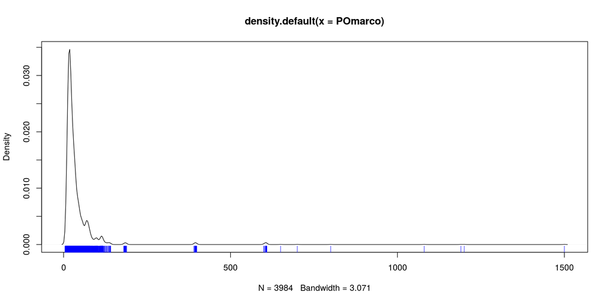

```r
plot(density(POmarco))
rug(POmarco, col= 'blue', ticksize = 0.03, lwd = 0.7)
```

Aquí se puede ver claramente la asimetría positiva que presenta la variable PO en el Marco completo.

Alternativamente, podemos usar un paquete como `moments`, que provee la función `skewness` para computar tercer momento centrado. En este caso, la asimetría de PO es de 11.0226797.

Observamos luego gráficamente la relación entre PO y VMP, en los datos de la Prueba Piloto:

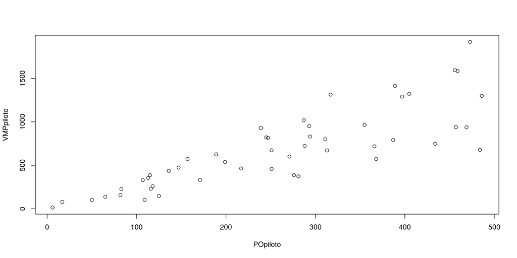

```r
plot(POpiloto, VMPpiloto)
```

Proponemos un modelo de regresión entre ambas variables, sin ordenada y asumiendo homocedasticidad:

$VMP_{i} = \beta PO_{i} + \epsilon_{i}$

```r
sinOrdenada <- lm(VMPpiloto ~ POpiloto + 0)
# Extraigo el coeficiente de las X (PO)
beta = sinOrdenada$coefficients["POpiloto"]
```

Ya en el gráfico anterior, la forma de “trompeta” nos hace sospechar la existencia de heterocedasticidad. Para comprobarlo, podemos graficar los residuos al cuadrado de la regresión:

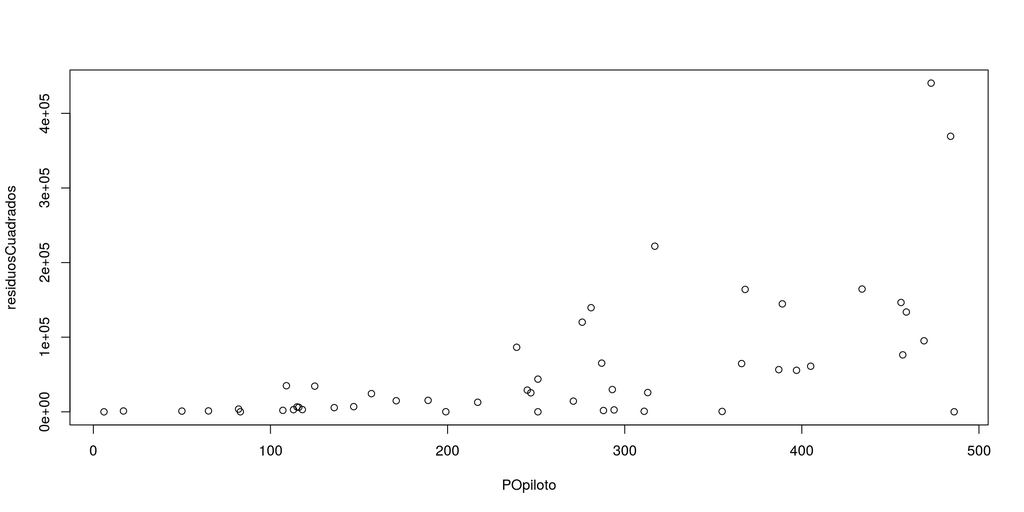

```r
residuosCuadrados = sinOrdenada$residuals ^ 2
plot(POpiloto, residuosCuadrados)
```

O aprovechar las capacidades del package `car`, que ofrece un bello gráfico de residuos de un modelo linear. En él se aprecia claramente como el módulo de los residuos aumenta con PO.

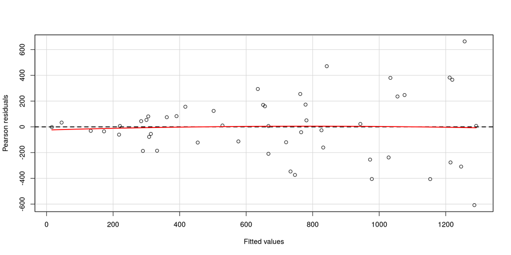

```r
# Es identico a `plot(PO, residuals(sinOrdenada))` pero mejor editado
residualPlot(sinOrdenada)
```

Una alternativa numérica, es computar el test de Breusch-Pagan de heterocedasticidad en el modelo. El p-valor que devuelve este test es 5.100248310^{-6}: siendo éste tan ínfimo, debemos debemos rechazar la hipotesis nula de homocedasticidaden el modelo.

## Ejercicio 2

### Enunciado

Aceptando la evidencia del punto 1 estimar según los datos provistos los parámetros “beta”, “sig2” y “gamma” necesarios para atender el modelo lineal simple de discrepancia en el algoritmo de Kozak. Recordar que “stratification” permite modelar $Y_{i} = \beta X_{i} + \epsilon_{i}$ con $\epsilon_{i} \sim N(0,\sigma_{i}^{2})$ y $\sigma_{i}^{2}=\sigma^{2}X_{i}^{\gamma}$ donde beta=$\beta$, sig2=$\sigma^{2}$ y gamma=$\gamma$ son parámetros que deben ser brindados por el usuario.

### Respuesta

El paquete `PracTools` provee una conveniente función llamda `gammaFit` para estimar el exponente de las X en una regresión lineal heterocedástica.

```r
# Estimacion de parametros para el algoritmo de Kozak
# Modo A: Utilizando PracTools::gammaFit
gammaA <- gammaFit(POpiloto, POpiloto, VMPpiloto)$g.hat
```

```
## Convergence attained in  3 steps.
## g.hat = 1.897834
```

Sin embargo, esto nos deja aún en la necesidad de estimar $\sigma^{2}$. Si asumimos que los residuos cuadrados del modelo homocedástico aproximan satisfactoriamiente los $\sigma_{i}^{2}$, podemos utilizar un modelo linear para aproximar $\sigma^{2}$ y $\gamma$:

$$\begin{align}
\sigma_{i}^{2} &= \sigma^{2}X_{i}^{\gamma} \\
\ln(\sigma_{i}^{2}) &= \ln(\sigma^{2}X_{i}^{\gamma}) \\
\ln(\sigma_{i}^{2}) &= \ln(\sigma^{2}) + \gamma \ln(X_{i})
\end{align}$$

Luego, $\gamma$ es el coeficiente $\ln(X_{i})$ que devuelve el modelo, y si el coeficiente independiente obtenido es $\alpha$, podemos calcular $\sigma^{2} = e^{\alpha}$:

```r
# Modo B: Asumiendo un modelo lineal entre log(residuosCuadrados) ~ log(x)
modeloResiduos <- lm(log(residuosCuadrados) ~ log(POpiloto))
gammaB <- modeloResiduos$coefficients["log(POpiloto)"]
sig2B <- exp(modeloResiduos$coefficients["(Intercept)"])
```

Comparando los resultados obtenidos, resulta que el valor de $\gamma$ obtenido por `gammaFit` es un poco mayor al que devuelve el modelado de los residuos: 1.8978338 versus 1.8537078. Dado que esto es un estudio práctico y sobre todo, *aproximado* de la relación entre una variable conocida, PO, y la que se pretende estudiar, VMP, preferiremos ser “pesimistas” y maximizar la estimación de la heterocedasticidad observada entre PO y VMP: es por ello que utilizaremos `gammaA` (1.8978338) como nuestro estimador de $\gamma$. Así, los tamaños muestrales que propongamos serán un poco mayores, más “holgados”, y minimizaremos la cantidad de sorpresas desagradables en el cómputo final de los CV.

## Ejercicio 3

### Enunciado

Con los valores estimados del punto 2 más las opciones (1) estudiar las alternativas de 2 hasta 5 estratos con respecto al tamaño de muestra final según la precisión deseada. Presente una tabla resumen con las distintas alternativas y con la siguiente información: opciones empleadas en el algoritmo, los bordes de los estratos surgidos del algoritmo, Nh y nh resultantes, los CV alcanzados en los estratos para la variable y el tamaño final de la muestra.

Donde las opciones (1) son: * CV=2%, * Asignación óptima de Neyman dentro de los estratos, * Un estrato de Autorepresentados, * Tasa de respuesta del orden del 80% en cada estrato, salvo en el de Autorepresentados, en cuyo caso y para este estrato en particular se asumirá respuesta total en todas las evaluaciones,

### Respuesta

En primer lugar, preparo las variables auxiliares que me permitirán pasar a la función `strata.LH` las opciones exigidos

```r
# Asignación óptima de Neyman por estrato
asigNeyman <- c(0.5, 0, 0.5)

# Armo vectores de no-respuesta para 2-5 estratos
rh2 <- c(rep(0.8, 1), 1)
rh3 <- c(rep(0.8, 2), 1)
rh4 <- c(rep(0.8, 3), 1)
rh5 <- c(rep(0.8, 4), 1)

# Parametros de control para utilizar Kozak con modelo lineal
parametrosKozak <- list(beta = beta, sig2 = sig2B, gamma = gammaA)
```

Luego, ejecuto la función optimizadora de bordes `strata.LH` para las alternativas de 2 a 5 estratos:

```r
# K{N} sera la variable que contenga los resultados de la estratificacion por Kozak para N estratos

K2 <- strata.LH(x = POmarco,
               CV = 0.02,
               Ls = 2,
               alloc = asigNeyman,
               takeall = 1,
               rh = rh2,
               model = "linear",
               model.control = parametrosKozak)
K3 <- strata.LH(x = POmarco,
               CV = 0.02,
               Ls = 3,
               alloc = asigNeyman,
               takeall = 1,
               rh = rh3,
               model = "linear",
               model.control = parametrosKozak)

K4 <- strata.LH(x = POmarco,
               CV = 0.02,
               Ls = 4,
               alloc = asigNeyman,
               takeall = 1,
               rh = rh4,
               model = "linear",
               model.control = parametrosKozak)

K5 <- strata.LH(x = POmarco,
               CV = 0.02,
               Ls = 5,
               alloc = asigNeyman,
               takeall = 1,
               rh = rh5,
               model = "linear",
               model.control = parametrosKozak)
```

Una parte de la información requerida en el enunciado (las opciones empleadas en el algoritmo) resultan evidentes en el bloque de código precedente. La información que imprime `strata.LH` por default cubre otros tantos requerimientos: * los bordes de los estratos surgidos (`bh`), * la existencia de estratos autorrepresentados (`type=='take-all'`), * la tasa de no respuesta por estrato (`rh`) * Nh y nh resultantes (literalmente, `Nh` y `nh`), y * el tamaño final de la muestra (mencionado como “Total Sample Size”)

También se provee el CV anticipado para el total de la muestra, pero en los requerimientos del enunciado se pide específicamente los CV alcanzados en cada estrato.

Sabiendo que para el estimador del total de Horvitz-Thompson
$$CV(\hat{X}) = \frac{\sqrt{Var(\hat{X})}}{E(\hat{X})}$$
donde
$$E(\hat{X}) = N\bar{x}$$
y
$$Var(\hat{X}) = N^{2} ( \frac{1}{n} - \frac{1}{N} ) S^{2}_{x}$$

Podemos aprovechar que `strata.LH` de por sí devuelve $\bar{x}$ (`mean`) y $S^{2}_{x}$ (`varh`) para computar los CV alcanzados por estrato con la siguiente función casera:

```r
CVestratos <- function(estratificacion) {
  CV <- sqrt(estratificacion$varh * (1/estratificacion$nh - 1/estratificacion$Nh)) / estratificacion$mean
  return(CV)
}

# Utilizamos la función recién definida para agregar un elemento más a los resultados anteriores
K2$CV <- CVestratos(K2)
K3$CV <- CVestratos(K3)
K4$CV <- CVestratos(K4)
K5$CV <- CVestratos(K5)
```

Finalmente, aunque de manera un poco verborrágica, estamos en condiciones de proveer toda la información solicitada:

#### Detalles de la optimizacion para 2 estratos

```
## Given arguments:
## x = POmarco
## CV = 0.02, Ls = 2, takenone = 0, takeall = 1
## allocation: q1 = 0.5, q2 = 0, q3 = 0.5
## model = linear: beta = 2.657332, sig2 = 0.5691583, gamma = 1.897834
## algo = Kozak: method = complete enumeration, minsol = 1000, idopti = nh, minNh = 2
##
## Strata information:
##           |      type  rh |     bh   E(Y)    Var(Y)   Nh  nh   fh
## stratum 1 | take-some 0.8 |   71.5  71.80   1899.52 3611 428 0.12
## stratum 2 |  take-all 1.0 | 1501.0 390.98 221893.61  373 373 1.00
## Total                                               3984 801 0.20
##
## Total sample size: 801
## Anticipated population mean: 101.6843
## Anticipated CV: 0.01997453
## Note: CV=RRMSE (Relative Root Mean Squared Error) because takenone=0.
```

#### Coeficientes de variación para 2 estratos

El ‘0’ final corresponde al último estrato, ‘takeall’.

```
## [1] 0.01945139 0.00000000
```

#### Detalles de la optimizacion para 3 estratos

```
## Given arguments:
## x = POmarco
## CV = 0.02, Ls = 3, takenone = 0, takeall = 1
## allocation: q1 = 0.5, q2 = 0, q3 = 0.5
## model = linear: beta = 2.657332, sig2 = 0.5691583, gamma = 1.897834
## algo = Kozak: minsol = 1000, idopti = nh, minNh = 2, maxiter = 10000,
##               maxstep = 17, maxstill = 170, rep = 5, trymany = TRUE
##
## Strata information:
##           |      type  rh |     bh   E(Y)    Var(Y)   Nh  nh   fh
## stratum 1 | take-some 0.8 |   39.5  56.57    646.77 2958 185 0.06
## stratum 2 | take-some 0.8 |  122.0 172.35   4909.67  948 163 0.17
## stratum 3 |  take-all 1.0 | 1501.0 953.91 642217.81   78  78 1.00
## Total                                               3984 426 0.11
##
## Total sample size: 426
## Anticipated population mean: 101.6843
## Anticipated CV: 0.01997876
## Note: CV=RRMSE (Relative Root Mean Squared Error) because takenone=0.
```

#### Coeficientes de variación para 3 estratos

```
## [1] 0.01780369 0.04911443 0.00000000
```

#### Detalles de la optimizacion para 4 estratos

```
## Given arguments:
## x = POmarco
## CV = 0.02, Ls = 4, takenone = 0, takeall = 1
## allocation: q1 = 0.5, q2 = 0, q3 = 0.5
## model = linear: beta = 2.657332, sig2 = 0.5691583, gamma = 1.897834
## algo = Kozak: minsol = 1000, idopti = nh, minNh = 2, maxiter = 10000,
##               maxstep = 17, maxstill = 170, rep = 5, trymany = TRUE
##
## Strata information:
##           |      type  rh |     bh    E(Y)    Var(Y)   Nh  nh   fh
## stratum 1 | take-some 0.8 |   25.5   45.44    279.39 2098  73 0.03
## stratum 2 | take-some 0.8 |   55.5   96.03    975.96 1257  82 0.07
## stratum 3 | take-some 0.8 |  140.5  214.42   5611.94  577  90 0.16
## stratum 4 |  take-all 1.0 | 1501.0 1256.82 684991.62   52  52 1.00
## Total                                                3984 297 0.07
##
## Total sample size: 297
## Anticipated population mean: 101.6843
## Anticipated CV: 0.01997216
## Note: CV=RRMSE (Relative Root Mean Squared Error) because takenone=0.
```

#### Coeficientes de variación para 4 estratos

```
## [1] 0.01890157 0.03280241 0.07134408 0.00000000
```

#### Detalles de la optimizacion para 5 estratos

```
## Given arguments:
## x = POmarco
## CV = 0.02, Ls = 5, takenone = 0, takeall = 1
## allocation: q1 = 0.5, q2 = 0, q3 = 0.5
## model = linear: beta = 2.657332, sig2 = 0.5691583, gamma = 1.897834
## algo = Kozak: minsol = 1000, idopti = nh, minNh = 2, maxiter = 10000,
##               maxstep = 17, maxstill = 170, rep = 5, trymany = TRUE
##
## Strata information:
##           |      type  rh |     bh    E(Y)    Var(Y)   Nh  nh   fh
## stratum 1 | take-some 0.8 |   23.5   43.45    239.56 1905  56 0.03
## stratum 2 | take-some 0.8 |   44.5   84.55    650.60 1218  59 0.05
## stratum 3 | take-some 0.8 |   82.5  161.02   2240.66  613  55 0.09
## stratum 4 | take-some 0.8 |  160.5  283.06   5618.88  198  28 0.14
## stratum 5 |  take-all 1.0 | 1501.0 1292.10 679746.96   50  50 1.00
## Total                                                3984 248 0.06
##
## Total sample size: 248
## Anticipated population mean: 101.6843
## Anticipated CV: 0.01991507
## Note: CV=RRMSE (Relative Root Mean Squared Error) because takenone=0.
```

#### Coeficientes de variación para 5 estratos

```
## [1] 0.02003933 0.03185627 0.05988791 0.12908735 0.00000000
```

## Ejercicio 4

### Enunciado

¿Cuál de las soluciones estudiadas aconsejaría si se pretende adoptar aquella que determina el menor tamaño muestral que satisface los requisitos de precisión?

### Respuesta

En todos los casos el CV total anticipado no supera la restricción de ser menor o igual al 2%. Los CV por estrato alcanzados no superan tampoco el 10%, con una sola excepción: el cuarto estrato de K5 tiene un CV de 12,9%.

Ateniéndonos al pie de la letra, **aconsejaremos adoptar la solución de cinco estratos**, que mantiene el CV total anticipado por debajo de 2% y tiene el N total más pequeño.

Sin embargo, no podemos dejar de advertir **ciertas señales de alarma**. Este análisis asume una población estática, sin nacimientos, defunciones y sobre todo, cambios de estrato para los individuos de la población. Este supuesto es en general poco realista, y si sospechamos que esta población particular podría incumplirlo, nos convendrá errar hacia lo seguro y elegir únicamente 4 estratos. Más aún, cuando como observamos anteriormente, uno de los estratos formados (el cuarto de los 5) tiene un CV bastante alto.

## Ejercicio 5

### Enunciado

Asigne cada empresa del universo respetando la estratificación que propuso en el punto 4 y seleccione la muestra según los tamaños por estrato definidos por el algoritmo. Acompañar la presentación del TP con la muestra seleccionada.

### Respuesta

Dados los bordes de estratos que contiene el objeto `K5`, podemos asignar a cada individuo del marco original el estrato que le corresponde con algunas operaciones:

```r
# Extraigo los nuevos ID de estratos y los combino con el Marco original
Estrato <- K5$stratumID
MarcoAsignado <- cbind(Marco.PO,Estrato)

# Genero una tabla resumen con los Pik por estrato
Pik <- K5$nh / K5$Nh
idEstratos <- c(1,2,3,4,5)

PikPorEstrato <- cbind.data.frame(idEstratos, Pik)
colnames(PikPorEstrato) <- c("Estrato","Pik")

# Combino el MarcoAsignado con los PikPorEstrato
MarcoAsignado <- merge(MarcoAsignado, PikPorEstrato)

# El comando `strata` permite elegir por MSA los individuos de cada estrato que participan de la muestra final,
# siempre y cuando se le provean los ID de estratos y las pik por indivduo
seleccion <- strata(MarcoAsignado,
                    stratanames="Estrato",
                    size=K5$nh,
                    method="srswor",
                    pik=MarcoAsignado$Pik)

# Finalmente, `getdata` filtra el Marco completo y devuelve únicamente la muestra antes generada
muestra <- getdata(MarcoAsignado,seleccion)
```

Para futura referencia, la muestra final se guarda en un archivo CSV:

```r
write.csv(muestra, file = 'data/muestraA.csv')

# Algunos elementos de muestra
sample_n(muestra, 10)
```

```
##        Uk  PO        Pik Estrato ID_unit       Prob Stratum
## 1823 3667  16 0.02939633       1    1823 0.02939633       1
## 1527 3843  19 0.02939633       1    1527 0.02939633       1
## 1771 3857  10 0.02939633       1    1771 0.02939633       1
## 3938 1534 182 1.00000000       5    3938 1.00000000       5
## 3973  300 604 1.00000000       5    3973 1.00000000       5
## 1471 3666  14 0.02939633       1    1471 0.02939633       1
## 1135 3330  13 0.02939633       1    1135 0.02939633       1
## 3286  599  77 0.08972268       3    3286 0.08972268       3
## 3455 1428  58 0.08972268       3    3455 0.08972268       3
## 356  2174  12 0.02939633       1     356 0.02939633       1
```

## Ejercicio 6

### Enunciado

Si se desea después de un año renovar el 20% de la muestra en los estratos donde no se censa, reteniendo parte de la muestra original y seleccionando a las nuevas unidades por MSA en cada estrato de $U_{h} - s_{h}$ , con $h = 1,...,H-1$ (el H es el *takeall*) y $s_{h}$ la muestra original en el estrato en cuestión. Proponer 2 alternativas para estimar la diferencia inter-anual $\hat{t}_{yt} − \hat{t}_{y(t−1)}$ entre dos totales de una misma característica. ¿Cómo estimaría las varianzas de dichos estimadores

### Respuesta

Siguiendo a Qualité y Tillé, si deseamos estimar específicamente la *diferencia* y no otras medidas relacionadas como el cambio relativo o el cociente entre los totales, tenemos fundamentalmente dos *approachs* posibles:

1. Estimar la diferencia a partir de los totales muestrales en cada período (lo que ellos llaman *“difference of the cross-sectional estimators”*, o
2. estimar la diferencia a partir de la “porción común” de las muestras.

En el trabajo de los autores, se proveen fórmulas para calcular la diferencia entre dos estimadores de Horvitz-Thompson para los totales de dos características (o una misma observada en dos momentos en el tiempo, como es nuestro caso), bajo *diseños sin estratificar*. Para poder aplicarlas a nuestro caso de uso, deberemos hacer las modificaciones necesarias para tomar en cuenta la estratificación propuesta. Esto va a llevar a una notación atiborrada, que intentaremos mantener tan clara como sea posible.

- Cuando expresemos sumatorias sobre la característica objetivo, omitiremos los subíndices. Así, escribiremos $\sum\limits_{U} y$ en lugar de $\sum\limits_{k \in U} y_{k}$.
- Hablaremos de $t_{yt_{1}}$ y $t_{yt_{0}}$ en lugar de $t_{yt}$ y $t_{y(t-1)}$, para poder referirnos a ambos $t$ en general.
- El símbolo $s$ puede resultar confuso, ya que en algunos casos se refiere a una muestra, y en otros al estimador de la varianza/covarianza para cierto conjunto de observaciones. En general, esta ambigüedad se resuelve teniendo en cuenta que siempre que $s$ aparezca debajo de $\sum$, será representando a una muestra, y siempre que aparezca en la línea principal de la ecuación, será como estimador.
- Habrá diversos subíndices que pueden afectar el significado de $s$, $N$, $n$, $Y$, $y$ o $\bar{y}$. Cada uno de ellos indica una “segmentación” distinta de la población o la muestra:
  - $t_{1}$ y $t_{0}$ (o $t$ en general) refieren a los momentos posterior o anterior en el tiempo,
  - $c$ refiere únicamente a la fracción en común que tienen las muestras (para un mismo estrato o completas) en $t_{1}$ y $t_{0}$
  - $h$ indica el estrato al que hacemos referencia.

Por ejemplo,

- $s_{c,h}$ es la porción en común intertemporalmente de ambas muestras, dentro de un estrato $h$ particular, y
- $\bar{y}_{t_{1},h}$ es la media de $y$ para el estrato $h$ en la muestra posterior ($t_{1}$).

Recordemos entonces, que buscamos estimadores de $\Delta = t_{yt_{1}} - t_{yt_{0}}$ donde $t_{y_{t}} = \sum_{U} y_{t}$ para $t \in \{t_{1}, t_{0}$

#### Estimador a partir de los totales muestrales

$$\hat{\Delta} = \hat{Y_{t_{1}}} - \hat{Y_{t_{0}}}$$

Donde

$$\hat{Y_{t}} = N \sum\limits_{h=1}^{H}\left[\frac{N_{h}}{N}\bar{y}_{t,h}\right]$$

Y

$$\bar{y}_{t,h} = \sum\limits_{s_{h,t}}\frac{y_{t}}{n_{h}}$$

Para todo $t \in \{t_{1}, t_{0}\}$ y $h \in \{1,\dots,H\}$

Si deseamos averiguar la varianza de este estimador, aprovechando que los $n_{c,h}$ (y por ende $N_{c}$) son conocidos y fijos entre $t_{1}$ y $t_{0}$, haremos:

$$\begin{align}
\widehat{Var}(\hat{\Delta}) &= N^2 \sum\limits_{h=1}^{H}\left[\left(\frac{N_{h}}{N}\right)^{2}\left(\frac{1}{n_{h}}-\frac{1}{N_{h}}\right)\left(s^{2}_{t_{1},h}+s^{2}_{t_{0},h}\right)\right] \\
&- 2 N^{2} \sum\limits_{h=1}^{H}\left[\left(\frac{N_{h}}{N}\right)^{2}\left(\frac{n_{c,h}}{n^{2}_{h}}-\frac{1}{N_{h}}\right)s_{t_{1},t_{0}c,h}\right]
\end{align}$$

Donde

$$\begin{align}
s^{2}_{t,h} &= \frac{1}{n_{h}-1} \sum\limits_{s_{h,t}}\left(y_{t} - \bar{y}_{t,h}\right)^{2} \\
s_{t_{1},t_{0},c,h} &= \frac{1}{n_{c,h}-1} \sum\limits_{s_{c,h}}\left(y_{t_{1}} - \bar{y}_{t_{1},c,h}\right)\left(y_{t_{0}} - \bar{y}_{t_{0},c,h}\right)
\end{align}$$

Y

$$\bar{y}_{t,c,h} = \sum\limits_{s_{c,h}}\frac{y_{t}}{n_{c,h}}$$

#### Estimador por la porción común

Otra alternativa, consiste en medir la variación promedio en la porción común de las muestras posterior y anterior, y luego multiplicar por el tamaño de la muestra completa (hecha las correspondientes ponderaciones por estrato). En este caso,

$$\hat{\Delta}_{c} = N \left(\bar{y}_{t_{1},c} - \bar{y}_{t_{0},c}\right)$$

Donde

$$\bar{y}_{t,c}=N_{c} \sum\limits_{h=1}^{H}\left[\frac{N_{c,h}}{N_{h}}\bar{y}_{t,c,h}\right]$$

Y $\bar{y}_{t,c,h}$ fue definido previamente.

Para estimar la varianza de $\hat{\Delta}_{c}$, tenemos:

$$\widehat{Var}(\hat{\Delta}_{c}) = N^2 \sum\limits_{h=1}^{H}\left[\left(\frac{N_{h}}{N}\right)^{2}\left(\frac{1}{n_{c,h}}-\frac{1}{N_{h}}\right)\left(s^{2}_{t_{1},c,h}+s^{2}_{t_{0},c,h}- 2 s_{t_{1},t_{0}c,h}\right)\right]$$

Donde

$$s^{2}_{t,c,h} = \frac{1}{n_{c,h}-1} \sum\limits_{s_{c,h}}\left(y_{t} - \bar{y}_{t,c,h}\right)^{2}$$

Y $s_{t_{1},t_{0}c,h}$ fue definido previamente.